# Patient validation of the tamoxifen-resistance signature

Does the cell-line resistance signature (`DE_analysis.Rmd`) predict outcome in patients?

- **Tamoxifen-treated:** GSE17705, 298 ER+ patients given adjuvant tamoxifen for 5 years (Symmans et al. 2010).
- **No endocrine therapy:** GSE2034, lymph-node-negative patients who received no adjuvant systemic therapy (Wang et al. 2005); ER+ patients only, outcome distant metastasis-free survival.

Both cohorts use the same Affymetrix HG-U133A array (GPL96). If a high score predicts relapse after tamoxifen but not without treatment, the signature reflects tamoxifen resistance rather than general prognosis.

```r
knitr::opts_knit$set(root.dir = here::here())
library(tidyverse)
library(here)
library(GEOquery)
library(survival)
dir.create(here("data/geo"), showWarnings = FALSE, recursive = TRUE)
dir.create(here("analysis/results/figures"), showWarnings = FALSE, recursive = TRUE)
dir.create(here("analysis/results/tables"), showWarnings = FALSE, recursive = TRUE)
```

## 1. Signature

```r
deg <- read_csv("analysis/results/tables/DESeq2_resistant_vs_parental.csv", show_col_types = FALSE) |>
  filter(padj < 0.05, abs(log2FoldChange) > 1, !is.na(gene_name))
up <- deg$gene_name[deg$log2FoldChange > 0]
down <- deg$gene_name[deg$log2FoldChange < 0]
c(up = length(up), down = length(down))
```

```
##   up down
##   95   39
```

## 2. Load cohorts

GSE17705 is read from GEO; its clinical columns are found by name and content. GEO’s GSE2034 record holds only bone relapse, so its full clinical data (ER status, distant metastasis-free survival, treatment) come from the Bioconductor package [breastCancerVDX](https://bioconductor.org/packages/breastCancerVDX/), which packages the same arrays. The table after this chunk shows which columns were used; check it.

```r
library(breastCancerVDX)

# First characteristics column whose name matches `pattern` (and not `exclude`) and whose values pass `ok`
find_col <- function(pd, pattern, ok, exclude = "^$") {
  cols <- names(pd)[str_detect(names(pd), regex(pattern, ignore_case = TRUE)) &
                      !str_detect(names(pd), regex(exclude, ignore_case = TRUE)) &
                      str_detect(names(pd), ":ch1$")]
  cols[map_lgl(cols, \(x) ok(pd[[x]]))][1]
}
is_num <- \(x) mean(!is.na(suppressWarnings(as.numeric(x)))) > 0.8
is_01 <- \(x) all(na.omit(x) %in% c("0", "1"))

# Probe -> gene symbol; keep uniquely mapped probes, then the probe with the highest mean per gene
collapse_probes <- function(x, sym) {
  if (max(x, na.rm = TRUE) > 100) x <- log2(pmax(x, 1))  # MAS5 values come unlogged
  keep <- !is.na(sym) & sym != "" & !str_detect(sym, "///")
  x <- x[keep, ]; sym <- sym[keep]
  best <- tapply(seq_along(sym), sym, \(i) i[which.max(rowMeans(x[i, , drop = FALSE]))])
  x <- x[unlist(best), ]
  rownames(x) <- names(best)
  x
}

load_geo <- function(gse) {
  eset <- getGEO(gse, destdir = "data/geo", GSEMatrix = TRUE, getGPL = TRUE)[[1]]
  pd <- pData(eset)
  time_col <- find_col(pd, "time|year|month|follow|surv", \(x) is_num(x) && !is_01(x))
  event_col <- find_col(pd, "relapse|event|recur|status|rfs", is_01, exclude = "time|year|month|bone")
  if (is.na(time_col) || is.na(event_col))
    stop(gse, ": could not find time/event columns. Characteristics: ",
         paste(grep(":ch1$", names(pd), value = TRUE), collapse = " | "))
  years <- as.numeric(pd[[time_col]]) / if (str_detect(time_col, regex("month", ignore_case = TRUE))) 12 else 1
  clin <- tibble(sample = rownames(pd), years = years, event = as.integer(pd[[event_col]]))
  list(clin = clin, expr = collapse_probes(exprs(eset), fData(eset)[["Gene Symbol"]])[, clin$sample],
       used = tibble(cohort = gse, time = time_col, event = event_col, filter = "none", n = nrow(clin)))
}

load_vdx <- function() {
  data(vdx, package = "breastCancerVDX")
  # VDX also contains ER- tumours from GSE5327; ER+ and untreated leaves the GSE2034 ER+ patients
  pd <- pData(vdx) |> filter(er == 1, treatment == 0, !is.na(t.dmfs), !is.na(e.dmfs))
  clin <- tibble(sample = rownames(pd), years = pd$t.dmfs / 365.25, event = as.integer(pd$e.dmfs))
  list(clin = clin, expr = collapse_probes(exprs(vdx), fData(vdx)$Gene.symbol)[, clin$sample],
       used = tibble(cohort = "GSE2034 (breastCancerVDX)", time = "t.dmfs (days)", event = "e.dmfs",
                     filter = "er == 1, treatment == 0", n = nrow(clin)))
}

cohorts <- list(`GSE17705 (tamoxifen)` = load_geo("GSE17705"),
                `GSE2034 (no endocrine therapy)` = load_vdx())
```

```
## Found 1 file(s)
```

```
## GSE17705_series_matrix.txt.gz
```

```
## Using locally cached version: data/geo/GSE17705_series_matrix.txt.gz
```

```
## Using locally cached version of GPL96 found here:
## data/geo/GPL96.soft.gz
```

```r
knitr::kable(map_dfr(cohorts, "used"))
```

| cohort | time | event | filter | n |
| --- | --- | --- | --- | --- |
| GSE17705 | event time (years):ch1 | distant relapse (1=dr, 0 censored):ch1 | none | 298 |
| GSE2034 (breastCancerVDX) | t.dmfs (days) | e.dmfs | er == 1, treatment == 0 | 209 |

## 3. Resistance score

Each gene is z-scored across patients within a cohort. The score is the mean z of the up genes minus the mean z of the down genes, so a higher score means a more resistant-like tumour. Follow-up is censored at 10 years so both cohorts cover the same window.

```r
score_cohort <- function(co) {
  z <- t(scale(t(co$expr)))
  co$clin |>
    mutate(score = colMeans(z[intersect(up, rownames(z)), , drop = FALSE]) -
                   colMeans(z[intersect(down, rownames(z)), , drop = FALSE]),
           event = if_else(years > 10, 0L, event),
           years = pmin(years, 10),
           group = factor(if_else(score > median(score), "High", "Low"), levels = c("Low", "High")))
}
scored <- map(cohorts, score_cohort)
map_dfr(cohorts, \(co) tibble(up_on_array = sum(up %in% rownames(co$expr)),
                              down_on_array = sum(down %in% rownames(co$expr))), .id = "cohort") |>
  knitr::kable()
```

| cohort | up_on_array | down_on_array |
| --- | --- | --- |
| GSE17705 (tamoxifen) | 60 | 15 |
| GSE2034 (no endocrine therapy) | 61 | 13 |

## 4. Survival

Cox model with the score per standard deviation, and Kaplan-Meier curves split at the median score.

```r
cox_tbl <- imap_dfr(scored, \(d, name) {
  fit <- summary(coxph(Surv(years, event) ~ scale(score), data = d))
  tibble(cohort = name, n = nrow(d), events = sum(d$event),
         HR_per_SD = fit$conf.int[1, 1], lower95 = fit$conf.int[1, 3], upper95 = fit$conf.int[1, 4],
         p = fit$coefficients[1, 5],
         logrank_p = 1 - pchisq(survdiff(Surv(years, event) ~ group, data = d)$chisq, 1))
})
write_csv(cox_tbl, "analysis/results/tables/patient_validation_cox.csv")
knitr::kable(cox_tbl, digits = 3)
```

| cohort | n | events | HR_per_SD | lower95 | upper95 | p | logrank_p |
| --- | --- | --- | --- | --- | --- | --- | --- |
| GSE17705 (tamoxifen) | 298 | 64 | 0.941 | 0.735 | 1.205 | 0.631 | 0.731 |
| GSE2034 (no endocrine therapy) | 209 | 80 | 1.263 | 1.003 | 1.591 | 0.047 | 0.211 |

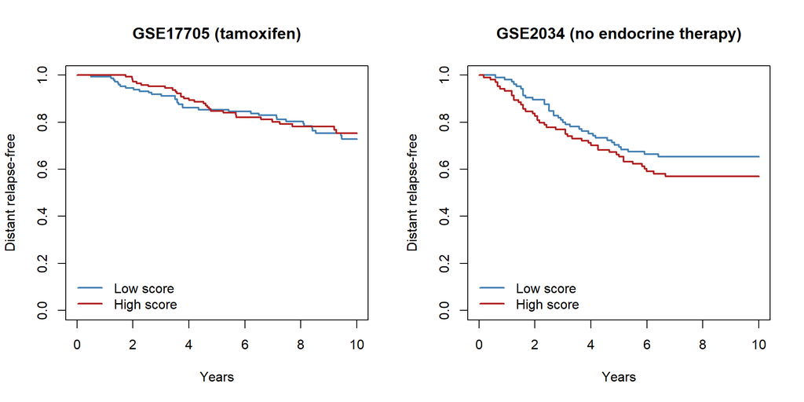

```r
km_plot <- function() {
  par(mfrow = c(1, 2))
  iwalk(scored, \(d, name) {
    plot(survfit(Surv(years, event) ~ group, data = d), col = c("steelblue", "firebrick"), lwd = 2,
         xlab = "Years", ylab = "Distant relapse-free", main = name)
    legend("bottomleft", c("Low score", "High score"), col = c("steelblue", "firebrick"), lwd = 2, bty = "n")
  })
}
png("analysis/results/figures/patient_validation_km.png", width = 10, height = 5, units = "in", res = 150)
km_plot(); invisible(dev.off())
km_plot()
```